# Capítulo 5

# 5 Destacando os outliers

Podemos destacar apenas os dados que queremos adicionando um subset no geom_text_repel

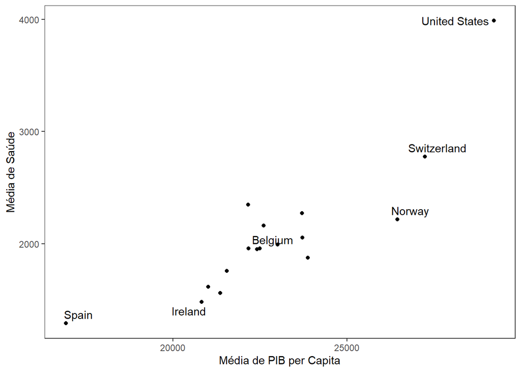

```r
q_9 <- ggplot(por_pais, aes(x = gdp_mean, y= health_mean))
q_9 +
  geom_point() +
  geom_text_repel(data = subset(por_pais,
                                gdp_mean >25000 | health_mean < 1500 | country %in% "Belgium"),
                  aes(label = country)) +
  theme_bw() +
  theme(panel.grid = element_blank()) +
  labs(x = "Média de PIB per Capita",
       y = "Média de Saúde")
```

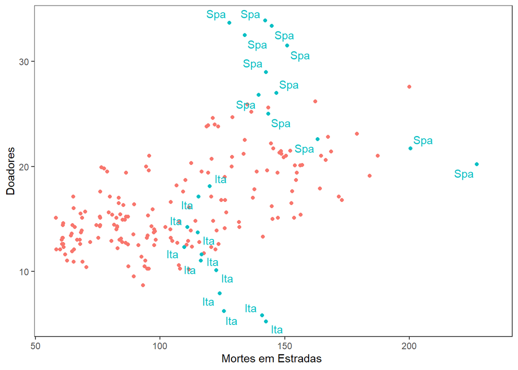

```r
organdata$ind <- organdata$ccode %in% c("Ita", "Spa") & organdata$year > 1998

q_10 <- ggplot(data = organdata,
               mapping = aes( x = roads,
                              y = donors,
                              color = ind))
q_10 + geom_point() +
  geom_text_repel(data = subset(organdata, ind),
                  mapping = aes(label = ccode)) +
  guides(label = "none", color = "none") +
  theme_bw() +
  theme(panel.grid = element_blank()) +
  labs(x = "Mortes em Estradas ",
       y = "Doadores")
```

# 6 Escrevendo e desenhando no gráfico

Podemos usar a função annotate para escrever no nosso gráfico

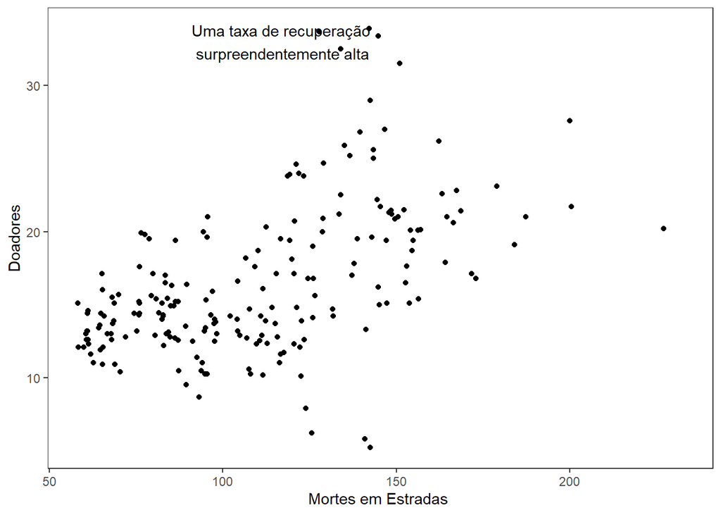

```r
q_11 <- ggplot(organdata, aes(x=roads, y = donors))
q_11 +
  geom_point() +
  theme_bw() +
  theme(panel.grid = element_blank()) +
  annotate(geom = "text", x = 91, y=33,
           label = "Uma taxa de recuperação \n surpreendentemente alta",
           hjust = 0) +
  labs(x = "Mortes em Estradas ",
       y = "Doadores")
```

Podemos adicionar mais do que texto e adicionar retângulos/linhas/segmentos/flechas

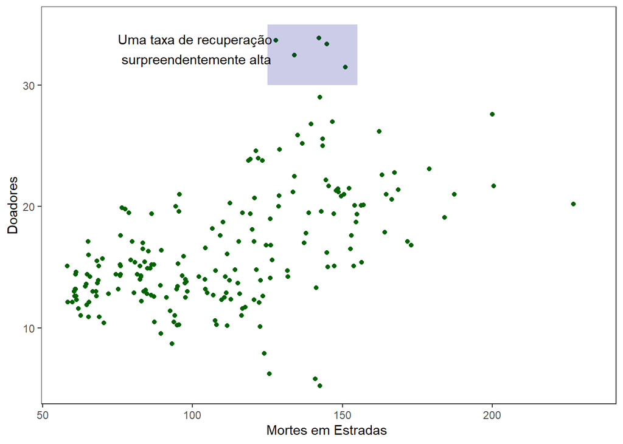

```r
q_11 +
  geom_point(color = "darkgreen") +
  annotate(geom = "rect", xmin = 125, xmax =155,
           ymin = 30, ymax=35, fill = "darkblue",
           alpha = 0.2) +
  theme_bw() +
  theme(panel.grid = element_blank()) +
  annotate(geom = "text", x = 75, y=33,
           label = "Uma taxa de recuperação \n surpreendentemente alta",
           hjust = 0 ) +
  labs(x = "Mortes em Estradas ",
       y = "Doadores")
```

# 7 Escalas, legendas e temas

Podemos ficar um pouco perdidos no ggplot pois temos varias maneiras de mexer com o gráfico. Estas maneiras são por meio das escalas, legendas e temas. Vamos entender como trabalhar com esses tipos variáveis no gráfico.

## 7.1 Mudando as coisas com scales

Podemos mudar as coisas que aparecem no scales com base na função scale. Basta inserirmos onde queremos que a função quebre e qual alegenda que querermos naquele lugar.

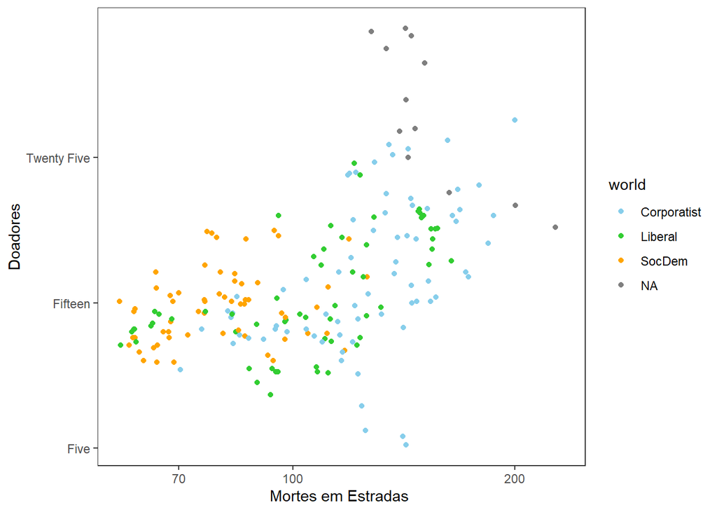

```r
q_12 <- ggplot(organdata, mapping = aes(x = roads,
                                        y=donors,
                                        color = world))
q_12 +
  geom_point() +
  scale_x_log10() +
  scale_y_continuous(breaks = c(5,15,25),
                     labels = c("Five",
                                "Fifteen",
                                "Twenty Five")) +
  theme_bw() +
  theme(panel.grid = element_blank()) +
  scale_color_manual(values = c("#87CEEB", "#32CD32", "#FFA500")) +
  labs(x = "Mortes em Estradas ",
       y = "Doadores")
```

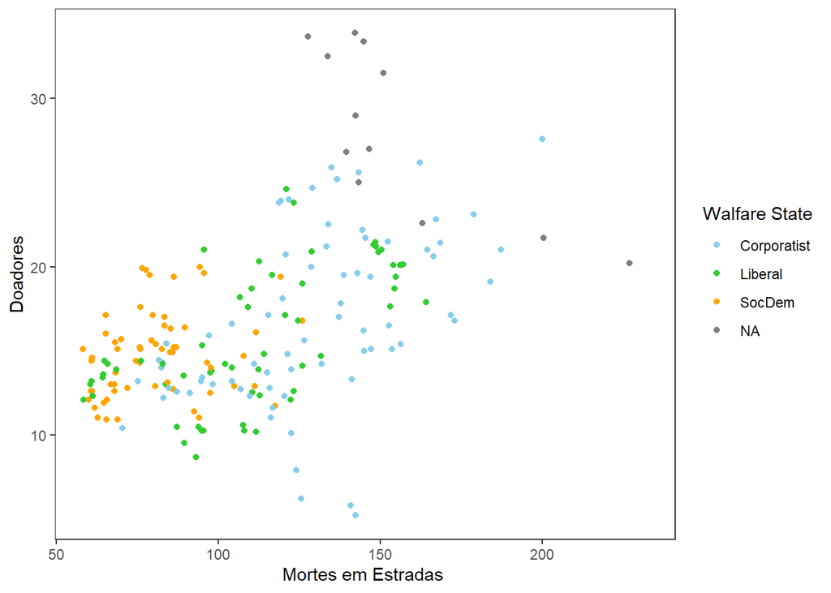

```r
q_12 +
  geom_point() +
  scale_color_discrete(labels = c("Corporatist",
                                  "Liberal",
                                  "Social Democracit",
                                  "Unclassified")) +
  labs(x = "Road Deaths",
       y= "Donor Procurement",
     color = "Walfare State") +
  theme_bw() +
  theme(panel.grid = element_blank()) +
  scale_color_manual(values = c("#87CEEB", "#32CD32", "#FFA500")) +
  labs(x = "Mortes em Estradas ",
       y = "Doadores")
```

## Tirando as legendas do gráfico Podemos tirar as legendas por meio da função guides(nome_dado_no_aesthetic = FALSE), podemos usar de exemplo o caso anterior

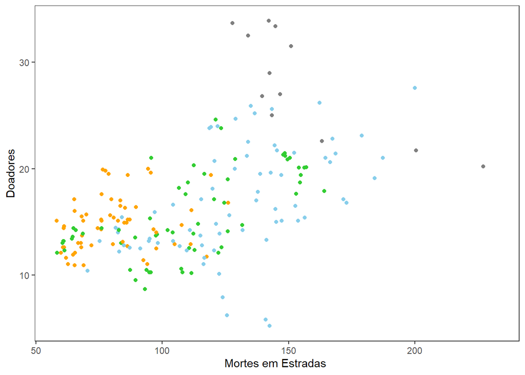

```r
q_12 +
  geom_point() +
  labs(x = "Road Deaths",
       y = "Donor Procurement") +
  guides(color = FALSE) +
  theme_bw() +
  theme(panel.grid = element_blank()) +
  scale_color_manual(values = c("#87CEEB", "#32CD32", "#FFA500")) +
  labs(x = "Mortes em Estradas ",
       y = "Doadores")
```